# Music Mood Analysis

### CS 418 - Team 11

#### Conrad Domagala, Juan Cruz, Tyler Strach, Ceasar Attar, Rovia Simmons, Andrea Carbonati

##### Github project repository: https://github.com/cs418-fa24/project-check-in-team-11

## Project Introduction

Our project aims to understand the spotify song classification/reccomendation algorithm and to see if it can be accurately recreated. Through gathering songs and their respective specific statistics from Spotify, we will determine what aspects of songs does Spotify use the most to determine the mood classification of songs. In turn, we will then evaluate whether or not an overall mood can be determined accurately from a user's liked songs library.

## Scope Adjustments

We wanted to try and recreate the Spotify wrapped, however that was a large scope and more tailored towards recreating a listening profile based on other non-song related data such as listening history, time of day, and artist preference. We pivoted the scope to focus on song related data such as track features revolving around tempo, loudness, energy, danceability, etc.

## Data Collection and Cleaning

This script uses the Spotify API to retrieve a user's saved (liked) tracks, along with their audio features, such as acousticness, danceability, energy, and tempo. The data is then processed and stored in a JSON file for further analysis. This information serves as a foundation for understanding mood classification based on Spotify's track features.

### Retrieve Liked Songs from Spotify

This script retrieves a user's liked (saved) songs from Spotify along with their audio features (e.g., tempo, energy, danceability). The data is then stored in a JSON file for further analysis.

**NOTE**: Refer to final_project.ipynb for full explanation (removed because notebook is too long) ####

```python
#### NOTE: Refer to final_project_scripts/liked_songs.py for code (removed because notebook is too long) ####
```

### Retrieve Spotify-Generated Playlists for Each Mood (Happy, Sad, Chill, Energetic)

This script retrieves Spotify playlists curated for specific moods (Happy, Sad, Chill, and Energetic) and extracts their audio features (e.g., tempo, danceability, valence). The data is stored in JSON files for further analysis.

**NOTE**: Refer to final_project.ipynb for full explanation (removed because notebook is too long) ####

```python
#### NOTE: Refer to final_project_scripts/mood_songs.py for code (removed because notebook is too long) ####
```

### Combine and Process Mood-Based Data into Dataframe

This script combines data from multiple JSON files containing Spotify mood-based playlists (Happy, Sad, Chill, Energetic) into a single dataset. It processes the data by assigning each song a corresponding mood label and dropping unnecessary columns.

**NOTE**: Refer to final_project.ipynb for full explanation (removed because notebook is too long) ####

```python
#### NOTE: Refer to final_project_scripts/mood_cleaning.py for code (removed because notebook is too long) ####
```

## Data Exploration

Our project's data consists of multiple JSON files, each representing different sets of Spotify songs categorized by moods such as chill, energetic, happy, and sad, along with a separate collection of liked songs from personal user libraries. These files contain attributes that are important in understanding song characteristics which may influence their mood classification, such as tempo, loudness, energy, danceability, and others.

In our preliminary analysis, we explored how these attributes distribute across various playlists to hypothesize which features might be most influential in determining a song's mood. We encountered significant challenges due to the size of the data files and API rate limits.

Interestingly, initial visualizations suggest clear distinctions in certain attributes among different mood-based playlists; for instance, songs in the happy playlist tend to have higher valence and tempo compared to those in the sad playlist. This aligns with our objective to differentiate between the patterns that could potentially recreate Spotify's mood classification logic. Moving forward, we plan to apply statistical tests to confirm these observations and refine our models accordingly, aiming to predict mood classifications with high accuracy.

```python
#### NOTE: Refer to final_project_scripts/liked_cleaning.py for code (removed because notebook is too long) ####
```

|  | acousticness | danceability | duration_ms | energy | instrumentalness | key | liveness | loudness | mode | speechiness | tempo | time_signature | valence |
| --- | --- | --- | --- | --- | --- | --- | --- | --- | --- | --- | --- | --- | --- |
| count | 2784.000000 | 2784.000000 | 2784.00000 | 2784.000000 | 2784.000000 | 2784.000000 | 2784.000000 | 2784.000000 | 2784.000000 | 2784.000000 | 2784.000000 | 2784.000000 | 2784.000000 |
| mean | 0.264226 | 0.673031 | 216885.16056 | 0.602474 | 0.181876 | 5.345905 | 0.179052 | -8.239840 | 0.544181 | 0.126167 | 118.323834 | 3.953305 | 0.527378 |
| std | 0.272244 | 0.159629 | 78603.04152 | 0.187366 | 0.321257 | 3.696630 | 0.137154 | 3.638828 | 0.498134 | 0.122564 | 27.905911 | 0.334789 | 0.240315 |
| min | 0.000003 | 0.000000 | 15967.00000 | 0.008580 | 0.000000 | 0.000000 | 0.019000 | -36.856000 | 0.000000 | 0.000000 | 0.000000 | 0.000000 | 0.000000 |
| 25% | 0.043000 | 0.580000 | 167217.75000 | 0.483000 | 0.000000 | 2.000000 | 0.096400 | -9.776250 | 0.000000 | 0.040400 | 96.051000 | 4.000000 | 0.344750 |
| 50% | 0.160500 | 0.700000 | 206033.50000 | 0.616000 | 0.000096 | 5.000000 | 0.124000 | -7.587000 | 1.000000 | 0.068300 | 117.046000 | 4.000000 | 0.533000 |
| 75% | 0.428000 | 0.787250 | 253346.50000 | 0.738000 | 0.194000 | 9.000000 | 0.217250 | -5.858500 | 1.000000 | 0.182000 | 136.008750 | 4.000000 | 0.724000 |
| max | 0.996000 | 0.978000 | 828560.00000 | 0.996000 | 0.973000 | 11.000000 | 0.983000 | 3.025000 | 1.000000 | 0.918000 | 215.449000 | 5.000000 | 0.981000 |

### Visualizing Feature Distributions Across Moods

This script generates a radar plot to compare the average values of various audio features (e.g., acousticness, energy, danceability) across moods like Happy, Sad, Chill, and Energetic. By normalizing and visualizing these features, the plot highlights distinct patterns in song characteristics that define each mood, helping in understanding how attributes contribute to mood classification.

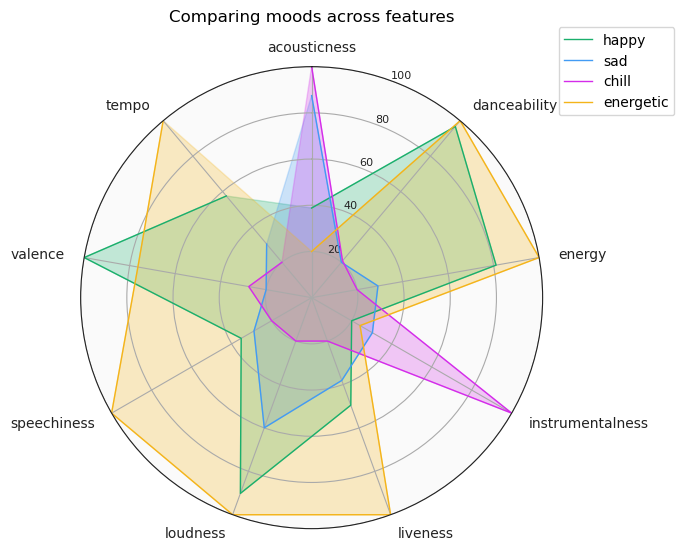

```python
#### NOTE: Refer to final_project_scripts/features_moods_radar.py for code (removed because notebook is too long) ####
```

### Mood-Specific Data Findings

#### Happy Songs

- High **danceability** (0.699) and **energy** (0.675) reflect lively, upbeat tracks.
- Positive emotional tone with a mean **valence** of 0.703.
- Low **acousticness** (0.228) suggests less acoustic, more electronic sound.

```python
happy_df = moods_df[moods_df['mood'] == 'happy']
happy_df.describe()
```

|  | acousticness | danceability | duration_ms | energy | instrumentalness | key | liveness | loudness | mode | speechiness | tempo | time_signature | valence |
| --- | --- | --- | --- | --- | --- | --- | --- | --- | --- | --- | --- | --- | --- |
| count | 300.000000 | 300.000000 | 300.000000 | 300.000000 | 300.000000 | 300.000000 | 300.000000 | 300.000000 | 300.000000 | 300.000000 | 300.000000 | 300.000000 | 300.000000 |
| mean | 0.228003 | 0.699980 | 194467.153333 | 0.675430 | 0.050095 | 5.266667 | 0.173191 | -6.669817 | 0.650000 | 0.076948 | 119.553113 | 3.980000 | 0.703342 |
| std | 0.221277 | 0.115443 | 45106.245635 | 0.147835 | 0.169320 | 3.488474 | 0.147277 | 2.635357 | 0.477767 | 0.086437 | 24.054849 | 0.230457 | 0.191693 |
| min | 0.000038 | 0.197000 | 60942.000000 | 0.166000 | 0.000000 | 0.000000 | 0.024600 | -22.602000 | 0.000000 | 0.026300 | 68.837000 | 1.000000 | 0.064600 |
| 25% | 0.042775 | 0.633000 | 169783.000000 | 0.567000 | 0.000000 | 2.000000 | 0.085575 | -7.986250 | 0.000000 | 0.036675 | 103.655750 | 4.000000 | 0.550750 |
| 50% | 0.165000 | 0.712000 | 197575.000000 | 0.683000 | 0.000007 | 5.000000 | 0.113000 | -6.220500 | 1.000000 | 0.045950 | 117.684000 | 4.000000 | 0.738000 |
| 75% | 0.352750 | 0.780250 | 218013.000000 | 0.791000 | 0.001670 | 8.250000 | 0.209500 | -4.873250 | 1.000000 | 0.077675 | 129.292500 | 4.000000 | 0.860000 |
| max | 0.972000 | 0.935000 | 473013.000000 | 0.991000 | 0.978000 | 11.000000 | 0.955000 | -1.931000 | 1.000000 | 0.711000 | 209.688000 | 5.000000 | 0.981000 |

#### Sad Songs

- High **acousticness** (0.523) indicates more acoustic elements.
- Lower **energy** (0.433) and **valence** (0.324) align with somber tones.
- Moderate **tempo** (114 BPM) supports reflective moods.

```python
sad_df = moods_df[moods_df['mood'] == 'sad']
# sad_df.describe()
```

#### Chill Songs

- High **acousticness** (0.599) and **instrumentalness** (0.681) create a calm, laid-back vibe.
- Lower **energy** (0.390) and softer **loudness** (-14.06 dB).
- Tracks favor acoustic and instrumental arrangements.

```python
chill_df = moods_df[moods_df['mood'] == 'chill']
# chill_df.head(5)
# chill_df.describe()
```

#### Energetic Songs

- High **energy** (0.764) and **tempo** (126 BPM) reflect vibrant, fast-paced tracks.
- Low **acousticness** (0.114) suggests digitally produced sounds.
- Uplifting tone with high **danceability** (0.706) and **valence** (0.591).

```python
energetic_df = moods_df[moods_df['mood'] == 'energetic']
# energetic_df.describe()
```

## Data Visualization

Our hypothesis is that certain song attributes are more prevalent in specific moods. To test this hypothesis, we visualized the distribution of song attributes across different moods. We focused on the following attributes: acousticness, danceability, energy, instrumentalness, liveness, loudness, speechiness, valence and tempo.

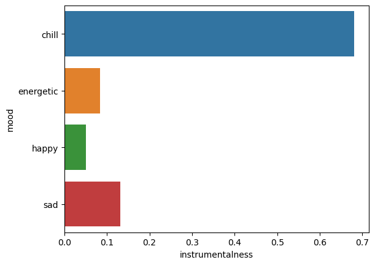

```python
import seaborn as sns

moods_mean_df = moods_df.groupby('mood').mean()
sns.barplot(moods_mean_df, x="instrumentalness", y="mood", hue="mood", legend=False)
```

```python
# sns.barplot(moods_mean_df, x="valence", y="mood", hue="mood", legend=False)
```

```python
# sns.barplot(moods_mean_df, x="speechiness", y="mood", hue="mood", legend=False)
```

```python
# sns.barplot(moods_mean_df, x="danceability", y="mood", hue="mood", legend=False)
```

```python
# sns.barplot(moods_mean_df, x="energy", y="mood", hue="mood", legend=False)
```

```python
# sns.barplot(moods_mean_df, x="tempo", y="mood", hue="mood", legend=False)
```

```python
# sns.barplot(moods_mean_df, x="loudness", y="mood", hue="mood", legend=False)
```

```python
# sns.barplot(moods_mean_df, x="liveness", y="mood", hue="mood", legend=False)
```

```python
# sns.barplot(moods_mean_df, x="acousticness", y="mood", hue="mood", legend=False)
```

### Bar Chart Analysis

These findings reinforce our understanding of how audio features define the characteristics of each mood.

### Hypothesis 2: Feature Correlations by Mood

We hypothesize that certain audio features are strongly correlated, and these correlations differ significantly across moods. For example:

- High **danceability** may correlate with high **energy** in Energetic songs.
- High **acousticness** might inversely correlate with **loudness** in Sad songs.

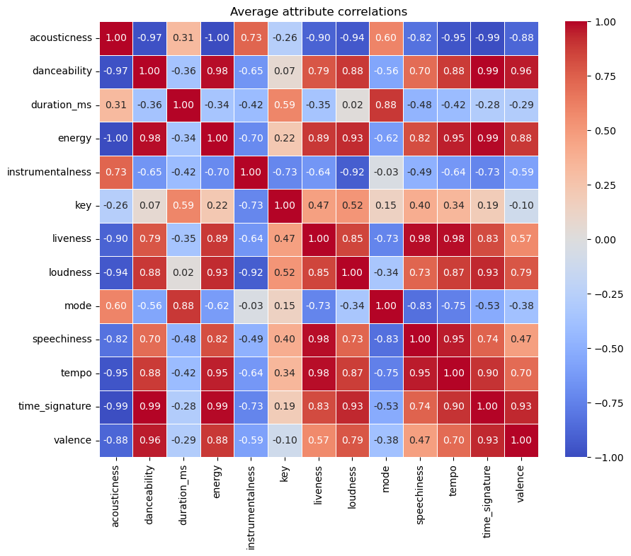

```python
def graph_corr(table, title):
    numeric_df = table.select_dtypes(include=['float64', 'int64'])
    plt.figure(figsize=(10, 8))
    plt.title(title)
    sns.heatmap(numeric_df.corr(), annot=True, cmap='coolwarm', fmt='.2f', linewidths=0.5, vmin=-1, vmax=1)
    plt.show()

graph_corr(moods_mean_df, 'Average attribute correlations')


# graph_corr(chill_df, 'Chill attribute correlations')
# graph_corr(energetic_df, 'Energetic attribute correlations')
# graph_corr(happy_df, 'Happy attribute correlations')
# graph_corr(sad_df, 'Sad attribute correlations')
```

### Correlation Analysis of Audio Features by Mood

#### Average Correlations

The overall correlation heatmap reveals strong relationships between certain features across all moods:

- **Energy** is strongly correlated with **danceability** and **loudness**, indicating that higher energy songs are typically more danceable and louder.
- **Acousticness** shows a negative correlation with **loudness** and **energy**, suggesting that quieter, less energetic songs are more acoustic.
- **Valence** (positivity) correlates positively with **energy** and **danceability**, especially in high-energy moods like Energetic and Happy.

**NOTE**: Refer to final_project.ipynb for full explanation (removed because notebook is too long) ####

## ML Data Analysis

### ML Data Preparation for Mood Classification

This section prepares the data for machine learning models to classify songs by mood based on audio features. The process includes:

#### Steps in the Data Preparation:

1. **Data Loading and Concatenation**:
   - JSON files for each mood (Happy, Sad, Chill, Energetic) are loaded and combined into a single DataFrame.
2. **Handling Duplicate Entries**:
   - Rows with conflicting moods for the same song (e.g., duplicates with different mood labels) are removed to ensure data consistency.
3. **Dropping Non-Feature Columns**:
   - Irrelevant columns (`name`, `id`) are dropped to retain only numerical audio features and the mood label.
4. **Encoding Mood Labels**:
   - Mood categories are encoded into numerical labels using `LabelEncoder`.
5. **Feature Scaling**:
   - Audio feature values are standardized using `StandardScaler` to ensure equal contribution to the model.
6. **Splitting the Dataset**:
   - Data is split into training (70%) and testing (30%) sets for model evaluation.
7. **Outlier Removal**:
   - Outliers in the training set are identified using z-scores and removed based on a threshold of 3 to improve model robustness.

This preprocessing pipeline ensures the dataset is clean, standardized, and ready for machine learning models to predict song moods accurately.

```python
#### NOTE: Refer to final_project_scripts/model_one_training.py for code (removed because notebook is too long) ####
```

### Model Training 1 - Baseline Regression Model

- **Logistic Regression** is used as a baseline classifier to evaluate the performance of a simple linear model on the dataset.
- Steps:
  1. The model is trained using the `X_train` and `y_train` datasets.
  2. Predictions are made on the `X_test` dataset.
  3. The model's performance is evaluated using:
     - **Classification Report** for precision, recall, F1-score, and support.
     - **Confusion Matrix** to visualize predictions versus actual labels.
     - **Cross-validation** to compute average accuracy across `k=10` folds.

```
Classification Report:
              precision    recall  f1-score   support

       chill       0.79      0.78      0.79        96
   energetic       0.59      0.67      0.62        75
       happy       0.64      0.55      0.59        89
         sad       0.69      0.72      0.70        74

    accuracy                           0.68       334
   macro avg       0.68      0.68      0.68       334
weighted avg       0.68      0.68      0.68       334


Accuracy Score:
0.6796407185628742

Confusion Matrix:
```

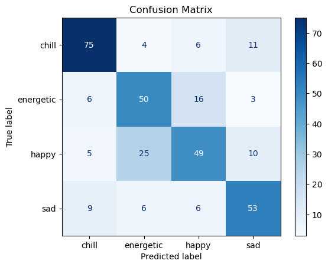

```
Logistic Regression Scores: [0.60714286 0.65765766 0.64864865 0.63963964 0.66666667 0.85585586
 0.81081081 0.69369369 0.72972973 0.69369369]
Average accuracy for 10 folds: 0.7004
```

```python
#### NOTE: Refer to final_project_scripts/model_one_report.py for code (removed because notebook is too long) ####
```

### Model Training 2.1- Selecting the Best Model

- A variety of classifiers are tested to determine the best-performing algorithm. These include:
  - RidgeClassifier, RandomForestClassifier, SVC, KNeighborsClassifier, GradientBoostingClassifier, and others.
- **Cross-validation** is performed for each classifier to compute mean accuracy scores.
- The classifier with the highest average accuracy is selected as the best-performing model for further evaluation.

```python
#### NOTE: Refer to final_project_scripts/model_2.1_selection.py for code (removed because notebook is too long) ####
```

```
RandomForestClassifier(random_state=1) 0.7574245472837022
```

### Model Training 2.2- RandomForestClassifier

- The **Random Forest Classifier** is chosen as the best-performing model in the previous step.
- Steps:
  1. The model is trained using the `X_train` and `y_train` datasets.
  2. Predictions are made on the `X_test` dataset.
  3. Model evaluation is performed using:
     - **Classification Report** and **Confusion Matrix**.
     - **Cross-validation** with `k=10` folds to validate consistency.

```
Classification Report:
              precision    recall  f1-score   support

       chill       0.87      0.76      0.81        96
   energetic       0.61      0.64      0.62        75
       happy       0.68      0.69      0.68        89
         sad       0.75      0.82      0.79        74

    accuracy                           0.73       334
   macro avg       0.73      0.73      0.73       334
weighted avg       0.73      0.73      0.73       334


Accuracy Score:
0.7275449101796407

Confusion Matrix:
```

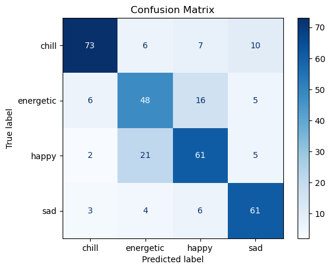

```
RandomForest CV Scores: [0.625      0.69369369 0.72072072 0.72072072 0.66666667 0.81981982
 0.8018018  0.82882883 0.85585586 0.8018018 ]
Average accuracy for 10 folds: 0.7535
```

```python
#### NOTE: Refer to final_project_scripts/model_2.2_random_forest.py for code (removed because notebook is too long) ####
```

### Model 3 - XGB Classifier

- The **XGBoost Classifier** is tested to compare its performance with the Random Forest and Logistic Regression models.
- Steps:
  1. Trained on `X_train` and `y_train` with `multi:softmax` for multiclass classification.
  2. Predictions are made on the `X_test` dataset.
  3. Performance evaluation includes:
     - **Classification Report** and **Confusion Matrix**.
     - **Cross-validation** with `k=5` folds to assess the stability of the model's accuracy.

```
Classification Report:
              precision    recall  f1-score   support

       chill       0.84      0.76      0.80        96
   energetic       0.65      0.68      0.67        75
       happy       0.63      0.64      0.63        89
         sad       0.74      0.78      0.76        74

    accuracy                           0.72       334
   macro avg       0.72      0.72      0.72       334
weighted avg       0.72      0.72      0.72       334


Accuracy Score:
0.7155688622754491

Confusion Matrix:
```

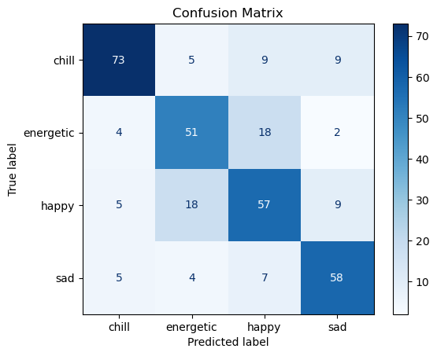

```
XGBoost CV Scores: [0.65470852 0.73423423 0.72072072 0.80630631 0.82882883]
Average XGBoost Accuracy: 0.7490
```

```python
#### NOTE: Refer to final_project_scripts/model_three.py for code (removed because notebook is too long) ####
```

### Key Insights

These models help analyze the dataset's complexity and identify the most suitable approach for mood classification based on audio features.

## ML Analysis on Each Member's 'Liked Songs'

### Purpose

```
-------------------------------------------------------------------------
Model 1 predictions:

Person 1 listens to mostly CHILL music. 47.54%. is of this mood.
Person 2 listens to mostly ENERGETIC music. 46.44%. is of this mood.
Person 3 listens to mostly HAPPY music. 42.59%. is of this mood.
Person 4 listens to mostly SAD music. 70.83%. is of this mood.
Person 5 listens to mostly ENERGETIC music. 52.0%. is of this mood.
Person 6 listens to mostly ENERGETIC music. 43.66%. is of this mood.
-------------------------------------------------------------------------
Model 2 predictions:

Person 1 listens to mostly CHILL music. 48.52%. is of this mood.
Person 2 listens to mostly ENERGETIC music. 43.65%. is of this mood.
Person 3 listens to mostly ENERGETIC music. 46.3%. is of this mood.
Person 4 listens to mostly SAD music. 64.58%. is of this mood.
Person 5 listens to mostly ENERGETIC music. 54.8%. is of this mood.
Person 6 listens to mostly ENERGETIC music. 39.55%. is of this mood.
-------------------------------------------------------------------------
Model 3 predictions:

Person 1 listens to mostly CHILL music. 48.72%. is of this mood.
Person 2 listens to mostly ENERGETIC music. 42.2%. is of this mood.
Person 3 listens to mostly ENERGETIC music. 42.59%. is of this mood.
Person 4 listens to mostly SAD music. 64.58%. is of this mood.
Person 5 listens to mostly ENERGETIC music. 55.8%. is of this mood.
Person 6 listens to mostly ENERGETIC music. 39.55%. is of this mood.
```

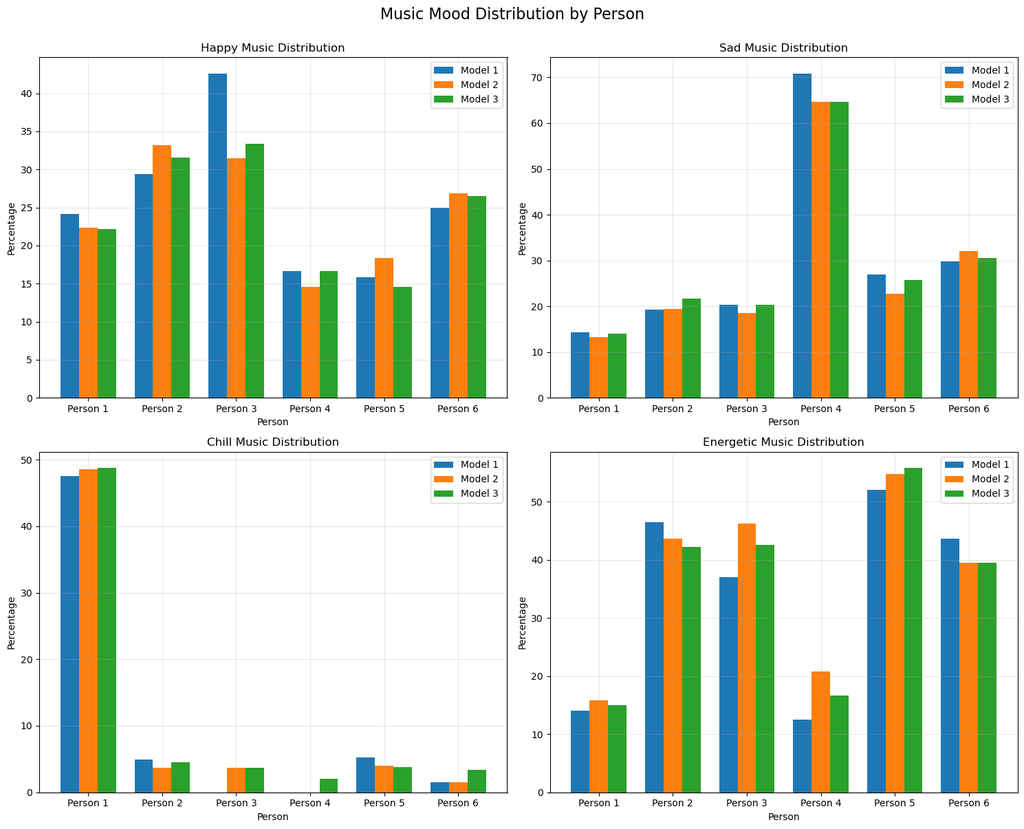

```python
#### NOTE: Refer to final_project_scripts/liked_songs_analysis.py for code (removed because notebook is too long) ####
```

### Insights

- The analysis highlights the mood preferences of each individual based on their listening history.
- Comparing predictions across models provides insights into their consistency and performance in real-world scenarios.
- Visualizations offer an intuitive understanding of mood distributions and model differences.

## Progress reflection

### Results

#### Analysis of Predictions:

Using the trained models (Logistic Regression, Random Forest, and XGBoost), we analyzed the predominant moods in each participant's liked songs library. Each model's predictions were used to classify the percentage distribution of four moods: **Happy**, **Sad**, **Chill**, and **Energetic**.

#### Inferences and Correlations:

- **Mood-Specific Attributes:**
  - "Happy" songs generally exhibit higher **tempo** and **energy**, aligning with initial insights from exploratory analysis.
  - "Sad" songs were more likely to have higher **acousticness** and lower **valence**, confirming their reflective nature.
- **Model-Specific Observations:**
  - Random Forest and XGBoost identified subtle patterns in the data that Logistic Regression overlooked, as evident in their higher accuracy and more balanced mood distributions.
- **User-Specific Findings:**
  - The mood predictions varied significantly between individuals, showcasing the diversity in music preferences. For example:
    - **Person 1** predominantly prefers "Chill" music (~47%).
    - **Person 4** has a strong inclination toward "Sad" music (~70%).

#### Challenges and Next Steps:

While the results demonstrate promising accuracy (~70%), there is room for improvement. Expanding the dataset and incorporating advanced features (e.g., spectrogram analysis) could further refine predictions.

This analysis successfully highlights the potential of machine learning in music classification, offering insights into mood patterns and preferences based on song features.

#### Hardest Part of the Project:

The most challenging aspect has been handling the large data sets and managing the Spotify API rate limits, which restricted our ability to retrieve data efficiently. These technical issues required a reevaluation of our data collection strategies, including implementing caching and batching requests to better manage API usage.

#### Roles and Coordination

**NOTE**: Refer to final_project.ipynb for full explanation (removed because notebook is too long) ####